# Risk Factor Analysis

## Outcome Variable

**Outcome Variable:** ever_stunted

## Predictor Variables

**Intervention Variable:** nchldlt5

**Adjustment Set:**

unadjusted

## Stratifying Variables

The analysis was stratified on these variable(s):

- agecat
- studyid
- country

## Data Summary

| agecat | studyid | country | nchldlt5 | ever_stunted | n_cell | n |
| --- | --- | --- | --- | --- | --- | --- |
| 0-24 months | iLiNS-Zinc | BURKINA FASO | 1 | 0 | 711 | 3188 |
| 0-24 months | iLiNS-Zinc | BURKINA FASO | 1 | 1 | 362 | 3188 |
| 0-24 months | iLiNS-Zinc | BURKINA FASO | 2+ | 0 | 1339 | 3188 |
| 0-24 months | iLiNS-Zinc | BURKINA FASO | 2+ | 1 | 776 | 3188 |
| 0-24 months | IRC | INDIA | 1 | 0 | 35 | 410 |
| 0-24 months | IRC | INDIA | 1 | 1 | 54 | 410 |
| 0-24 months | IRC | INDIA | 2+ | 0 | 112 | 410 |
| 0-24 months | IRC | INDIA | 2+ | 1 | 209 | 410 |
| 0-24 months | JiVitA-3 | BANGLADESH | 1 | 0 | 8536 | 27200 |
| 0-24 months | JiVitA-3 | BANGLADESH | 1 | 1 | 8874 | 27200 |
| 0-24 months | JiVitA-3 | BANGLADESH | 2+ | 0 | 5189 | 27200 |
| 0-24 months | JiVitA-3 | BANGLADESH | 2+ | 1 | 4601 | 27200 |
| 0-24 months | LCNI-5 | MALAWI | 1 | 0 | 145 | 812 |
| 0-24 months | LCNI-5 | MALAWI | 1 | 1 | 246 | 812 |
| 0-24 months | LCNI-5 | MALAWI | 2+ | 0 | 150 | 812 |
| 0-24 months | LCNI-5 | MALAWI | 2+ | 1 | 271 | 812 |
| 0-24 months | NIH-Crypto | BANGLADESH | 1 | 0 | 298 | 758 |
| 0-24 months | NIH-Crypto | BANGLADESH | 1 | 1 | 243 | 758 |
| 0-24 months | NIH-Crypto | BANGLADESH | 2+ | 0 | 98 | 758 |
| 0-24 months | NIH-Crypto | BANGLADESH | 2+ | 1 | 119 | 758 |
| 0-24 months | PROVIDE | BANGLADESH | 1 | 0 | 295 | 700 |
| 0-24 months | PROVIDE | BANGLADESH | 1 | 1 | 217 | 700 |
| 0-24 months | PROVIDE | BANGLADESH | 2+ | 0 | 100 | 700 |
| 0-24 months | PROVIDE | BANGLADESH | 2+ | 1 | 88 | 700 |
| 0-24 months | TanzaniaChild2 | TANZANIA, UNITED REPUBLIC OF | 1 | 0 | 1077 | 2385 |
| 0-24 months | TanzaniaChild2 | TANZANIA, UNITED REPUBLIC OF | 1 | 1 | 560 | 2385 |
| 0-24 months | TanzaniaChild2 | TANZANIA, UNITED REPUBLIC OF | 2+ | 0 | 481 | 2385 |
| 0-24 months | TanzaniaChild2 | TANZANIA, UNITED REPUBLIC OF | 2+ | 1 | 267 | 2385 |
| 0-6 months | IRC | INDIA | 1 | 0 | 49 | 410 |
| 0-6 months | IRC | INDIA | 1 | 1 | 40 | 410 |
| 0-6 months | IRC | INDIA | 2+ | 0 | 187 | 410 |
| 0-6 months | IRC | INDIA | 2+ | 1 | 134 | 410 |
| 0-6 months | JiVitA-3 | BANGLADESH | 1 | 0 | 9780 | 27134 |
| 0-6 months | JiVitA-3 | BANGLADESH | 1 | 1 | 7579 | 27134 |
| 0-6 months | JiVitA-3 | BANGLADESH | 2+ | 0 | 6146 | 27134 |
| 0-6 months | JiVitA-3 | BANGLADESH | 2+ | 1 | 3629 | 27134 |
| 0-6 months | LCNI-5 | MALAWI | 1 | 0 | 81 | 267 |
| 0-6 months | LCNI-5 | MALAWI | 1 | 1 | 41 | 267 |
| 0-6 months | LCNI-5 | MALAWI | 2+ | 0 | 91 | 267 |
| 0-6 months | LCNI-5 | MALAWI | 2+ | 1 | 54 | 267 |
| 0-6 months | NIH-Crypto | BANGLADESH | 1 | 0 | 386 | 758 |
| 0-6 months | NIH-Crypto | BANGLADESH | 1 | 1 | 155 | 758 |
| 0-6 months | NIH-Crypto | BANGLADESH | 2+ | 0 | 143 | 758 |
| 0-6 months | NIH-Crypto | BANGLADESH | 2+ | 1 | 74 | 758 |
| 0-6 months | PROVIDE | BANGLADESH | 1 | 0 | 383 | 700 |
| 0-6 months | PROVIDE | BANGLADESH | 1 | 1 | 129 | 700 |
| 0-6 months | PROVIDE | BANGLADESH | 2+ | 0 | 149 | 700 |
| 0-6 months | PROVIDE | BANGLADESH | 2+ | 1 | 39 | 700 |
| 0-6 months | TanzaniaChild2 | TANZANIA, UNITED REPUBLIC OF | 1 | 0 | 1311 | 2385 |
| 0-6 months | TanzaniaChild2 | TANZANIA, UNITED REPUBLIC OF | 1 | 1 | 326 | 2385 |
| 0-6 months | TanzaniaChild2 | TANZANIA, UNITED REPUBLIC OF | 2+ | 0 | 609 | 2385 |
| 0-6 months | TanzaniaChild2 | TANZANIA, UNITED REPUBLIC OF | 2+ | 1 | 139 | 2385 |
| 6-24 months | iLiNS-Zinc | BURKINA FASO | 1 | 0 | 711 | 3188 |
| 6-24 months | iLiNS-Zinc | BURKINA FASO | 1 | 1 | 362 | 3188 |
| 6-24 months | iLiNS-Zinc | BURKINA FASO | 2+ | 0 | 1339 | 3188 |
| 6-24 months | iLiNS-Zinc | BURKINA FASO | 2+ | 1 | 776 | 3188 |
| 6-24 months | IRC | INDIA | 1 | 0 | 35 | 236 |
| 6-24 months | IRC | INDIA | 1 | 1 | 14 | 236 |
| 6-24 months | IRC | INDIA | 2+ | 0 | 112 | 236 |
| 6-24 months | IRC | INDIA | 2+ | 1 | 75 | 236 |
| 6-24 months | JiVitA-3 | BANGLADESH | 1 | 0 | 5238 | 10487 |
| 6-24 months | JiVitA-3 | BANGLADESH | 1 | 1 | 1295 | 10487 |
| 6-24 months | JiVitA-3 | BANGLADESH | 2+ | 0 | 2982 | 10487 |
| 6-24 months | JiVitA-3 | BANGLADESH | 2+ | 1 | 972 | 10487 |
| 6-24 months | LCNI-5 | MALAWI | 1 | 0 | 138 | 705 |
| 6-24 months | LCNI-5 | MALAWI | 1 | 1 | 205 | 705 |
| 6-24 months | LCNI-5 | MALAWI | 2+ | 0 | 145 | 705 |
| 6-24 months | LCNI-5 | MALAWI | 2+ | 1 | 217 | 705 |
| 6-24 months | NIH-Crypto | BANGLADESH | 1 | 0 | 280 | 506 |
| 6-24 months | NIH-Crypto | BANGLADESH | 1 | 1 | 88 | 506 |
| 6-24 months | NIH-Crypto | BANGLADESH | 2+ | 0 | 93 | 506 |
| 6-24 months | NIH-Crypto | BANGLADESH | 2+ | 1 | 45 | 506 |
| 6-24 months | PROVIDE | BANGLADESH | 1 | 0 | 238 | 456 |
| 6-24 months | PROVIDE | BANGLADESH | 1 | 1 | 88 | 456 |
| 6-24 months | PROVIDE | BANGLADESH | 2+ | 0 | 81 | 456 |
| 6-24 months | PROVIDE | BANGLADESH | 2+ | 1 | 49 | 456 |
| 6-24 months | TanzaniaChild2 | TANZANIA, UNITED REPUBLIC OF | 1 | 0 | 858 | 1596 |
| 6-24 months | TanzaniaChild2 | TANZANIA, UNITED REPUBLIC OF | 1 | 1 | 234 | 1596 |
| 6-24 months | TanzaniaChild2 | TANZANIA, UNITED REPUBLIC OF | 2+ | 0 | 376 | 1596 |
| 6-24 months | TanzaniaChild2 | TANZANIA, UNITED REPUBLIC OF | 2+ | 1 | 128 | 1596 |

The following strata were considered:

- agecat: 0-24 months, studyid: iLiNS-Zinc, country: BURKINA FASO
- agecat: 0-24 months, studyid: IRC, country: INDIA
- agecat: 0-24 months, studyid: JiVitA-3, country: BANGLADESH
- agecat: 0-24 months, studyid: LCNI-5, country: MALAWI
- agecat: 0-24 months, studyid: NIH-Crypto, country: BANGLADESH
- agecat: 0-24 months, studyid: PROVIDE, country: BANGLADESH
- agecat: 0-24 months, studyid: TanzaniaChild2, country: TANZANIA, UNITED REPUBLIC OF
- agecat: 0-6 months, studyid: IRC, country: INDIA
- agecat: 0-6 months, studyid: JiVitA-3, country: BANGLADESH
- agecat: 0-6 months, studyid: LCNI-5, country: MALAWI
- agecat: 0-6 months, studyid: NIH-Crypto, country: BANGLADESH
- agecat: 0-6 months, studyid: PROVIDE, country: BANGLADESH
- agecat: 0-6 months, studyid: TanzaniaChild2, country: TANZANIA, UNITED REPUBLIC OF
- agecat: 6-24 months, studyid: iLiNS-Zinc, country: BURKINA FASO
- agecat: 6-24 months, studyid: IRC, country: INDIA
- agecat: 6-24 months, studyid: JiVitA-3, country: BANGLADESH
- agecat: 6-24 months, studyid: LCNI-5, country: MALAWI
- agecat: 6-24 months, studyid: NIH-Crypto, country: BANGLADESH
- agecat: 6-24 months, studyid: PROVIDE, country: BANGLADESH
- agecat: 6-24 months, studyid: TanzaniaChild2, country: TANZANIA, UNITED REPUBLIC OF

## Methods Detail

We’re interested in the causal parameters $E[Y_a]$ for all values of $a \in \mathcal{A}$. These parameters represent the mean outcome if, possibly contrary to fact, we intervened to set all units to have $A=a$. Under the randomization and positivity assumptions, these are identified by the statistical parameters $\psi_a=E_W[E_{Y|A,W}(Y|A=a,W)]$. In addition, we’re interested in the mean of $Y$, $E[Y]$ under no intervention (the observed mean). We will estimate these parameters by using SuperLearner to fit the relevant likelihood factors – $E_{Y|A,W}(Y|A=a,W)$ and $p(A=a|W)$, and then updating our likelihood fit using a joint TMLE.

For unadjusted analyses ($W=\{\}$), initial likelihoods were estimated using Lrnr_glm to estimate the simple $E(Y|A)$ and Lrnr_mean to estimate $p(A)$. For adjusted analyses, a small library containing Lrnr_glmnet, Lrnr_xgboost, and Lrnr_mean was used.

Having estimated these parameters, we will then use the delta method to estimate relative risks and attributable risks relative to a prespecified baseline level of $A$.

# Results Detail

## Results Plots

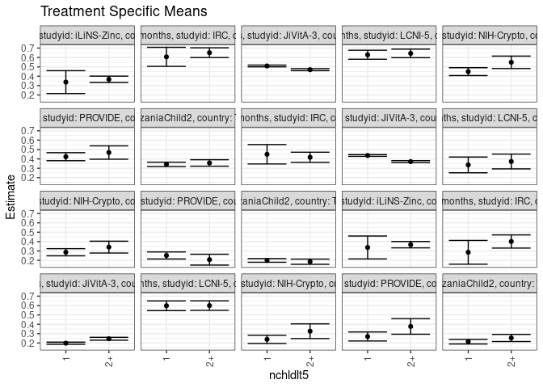

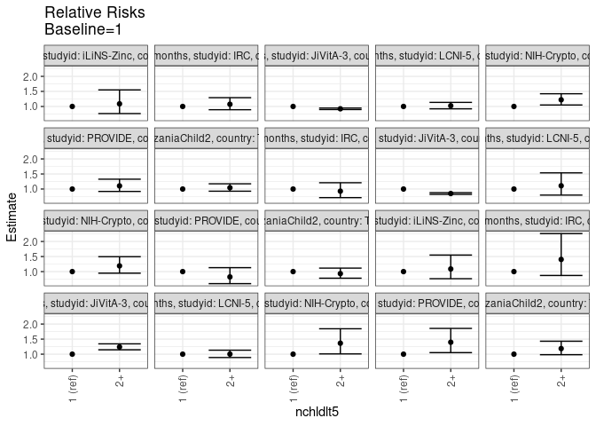

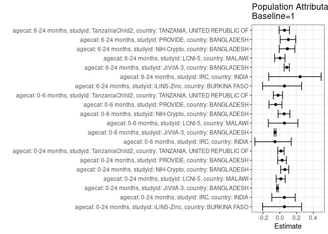

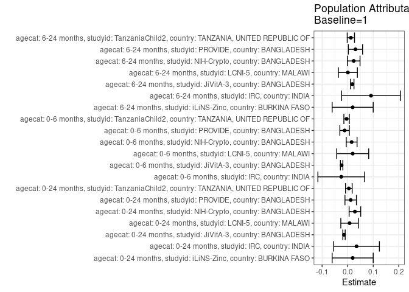

## Results Table

### Parameter: TSM

| agecat | studyid | country | intervention_level | baseline_level | estimate | ci_lower | ci_upper |
| --- | --- | --- | --- | --- | --- | --- | --- |
| 0-24 months | iLiNS-Zinc | BURKINA FASO | 1 | NA | 0.3373719 | 0.2153826 | 0.4593611 |
| 0-24 months | iLiNS-Zinc | BURKINA FASO | 2+ | NA | 0.3669031 | 0.3330207 | 0.4007854 |
| 0-24 months | IRC | INDIA | 1 | NA | 0.6067416 | 0.5051344 | 0.7083487 |
| 0-24 months | IRC | INDIA | 2+ | NA | 0.6510903 | 0.5988864 | 0.7032942 |
| 0-24 months | JiVitA-3 | BANGLADESH | 1 | NA | 0.5097071 | 0.5002375 | 0.5191766 |
| 0-24 months | JiVitA-3 | BANGLADESH | 2+ | NA | 0.4699694 | 0.4590563 | 0.4808824 |
| 0-24 months | LCNI-5 | MALAWI | 1 | NA | 0.6291560 | 0.5812487 | 0.6770634 |
| 0-24 months | LCNI-5 | MALAWI | 2+ | NA | 0.6437055 | 0.5979310 | 0.6894799 |
| 0-24 months | NIH-Crypto | BANGLADESH | 1 | NA | 0.4491682 | 0.4072261 | 0.4911103 |
| 0-24 months | NIH-Crypto | BANGLADESH | 2+ | NA | 0.5483871 | 0.4821301 | 0.6146441 |
| 0-24 months | PROVIDE | BANGLADESH | 1 | NA | 0.4238281 | 0.3809936 | 0.4666627 |
| 0-24 months | PROVIDE | BANGLADESH | 2+ | NA | 0.4680851 | 0.3967073 | 0.5394629 |
| 0-24 months | TanzaniaChild2 | TANZANIA, UNITED REPUBLIC OF | 1 | NA | 0.3420892 | 0.3191029 | 0.3650754 |
| 0-24 months | TanzaniaChild2 | TANZANIA, UNITED REPUBLIC OF | 2+ | NA | 0.3569519 | 0.3226107 | 0.3912930 |
| 0-6 months | IRC | INDIA | 1 | NA | 0.4494382 | 0.3459665 | 0.5529099 |
| 0-6 months | IRC | INDIA | 2+ | NA | 0.4174455 | 0.3634330 | 0.4714580 |
| 0-6 months | JiVitA-3 | BANGLADESH | 1 | NA | 0.4366035 | 0.4273238 | 0.4458832 |
| 0-6 months | JiVitA-3 | BANGLADESH | 2+ | NA | 0.3712532 | 0.3606481 | 0.3818583 |
| 0-6 months | LCNI-5 | MALAWI | 1 | NA | 0.3360656 | 0.2520891 | 0.4200420 |
| 0-6 months | LCNI-5 | MALAWI | 2+ | NA | 0.3724138 | 0.2935771 | 0.4512505 |
| 0-6 months | NIH-Crypto | BANGLADESH | 1 | NA | 0.2865065 | 0.2483825 | 0.3246305 |
| 0-6 months | NIH-Crypto | BANGLADESH | 2+ | NA | 0.3410138 | 0.2778993 | 0.4041283 |
| 0-6 months | PROVIDE | BANGLADESH | 1 | NA | 0.2519531 | 0.2143219 | 0.2895843 |
| 0-6 months | PROVIDE | BANGLADESH | 2+ | NA | 0.2074468 | 0.1494442 | 0.2654494 |
| 0-6 months | TanzaniaChild2 | TANZANIA, UNITED REPUBLIC OF | 1 | NA | 0.1991448 | 0.1797950 | 0.2184946 |
| 0-6 months | TanzaniaChild2 | TANZANIA, UNITED REPUBLIC OF | 2+ | NA | 0.1858289 | 0.1579482 | 0.2137095 |
| 6-24 months | iLiNS-Zinc | BURKINA FASO | 1 | NA | 0.3373719 | 0.2153826 | 0.4593611 |
| 6-24 months | iLiNS-Zinc | BURKINA FASO | 2+ | NA | 0.3669031 | 0.3330207 | 0.4007854 |
| 6-24 months | IRC | INDIA | 1 | NA | 0.2857143 | 0.1589567 | 0.4124719 |
| 6-24 months | IRC | INDIA | 2+ | NA | 0.4010695 | 0.3306736 | 0.4714654 |
| 6-24 months | JiVitA-3 | BANGLADESH | 1 | NA | 0.1982244 | 0.1870495 | 0.2093993 |
| 6-24 months | JiVitA-3 | BANGLADESH | 2+ | NA | 0.2458270 | 0.2308085 | 0.2608455 |
| 6-24 months | LCNI-5 | MALAWI | 1 | NA | 0.5976676 | 0.5457360 | 0.6495992 |
| 6-24 months | LCNI-5 | MALAWI | 2+ | NA | 0.5994475 | 0.5489340 | 0.6499610 |
| 6-24 months | NIH-Crypto | BANGLADESH | 1 | NA | 0.2391304 | 0.1955064 | 0.2827545 |
| 6-24 months | NIH-Crypto | BANGLADESH | 2+ | NA | 0.3260870 | 0.2477969 | 0.4043770 |
| 6-24 months | PROVIDE | BANGLADESH | 1 | NA | 0.2699387 | 0.2216963 | 0.3181810 |
| 6-24 months | PROVIDE | BANGLADESH | 2+ | NA | 0.3769231 | 0.2935261 | 0.4603201 |
| 6-24 months | TanzaniaChild2 | TANZANIA, UNITED REPUBLIC OF | 1 | NA | 0.2142857 | 0.1899412 | 0.2386303 |
| 6-24 months | TanzaniaChild2 | TANZANIA, UNITED REPUBLIC OF | 2+ | NA | 0.2539683 | 0.2159548 | 0.2919817 |

### Parameter: E(Y)

| agecat | studyid | country | intervention_level | baseline_level | estimate | ci_lower | ci_upper |
| --- | --- | --- | --- | --- | --- | --- | --- |
| 0-24 months | iLiNS-Zinc | BURKINA FASO | NA | NA | 0.3569636 | 0.3068991 | 0.4070281 |
| 0-24 months | IRC | INDIA | NA | NA | 0.6414634 | 0.5949863 | 0.6879405 |
| 0-24 months | JiVitA-3 | BANGLADESH | NA | NA | 0.4954044 | 0.4875673 | 0.5032416 |
| 0-24 months | LCNI-5 | MALAWI | NA | NA | 0.6366995 | 0.6035988 | 0.6698003 |
| 0-24 months | NIH-Crypto | BANGLADESH | NA | NA | 0.4775726 | 0.4419904 | 0.5131548 |
| 0-24 months | PROVIDE | BANGLADESH | NA | NA | 0.4357143 | 0.3989556 | 0.4724730 |
| 0-24 months | TanzaniaChild2 | TANZANIA, UNITED REPUBLIC OF | NA | NA | 0.3467505 | 0.3276457 | 0.3658553 |
| 0-6 months | IRC | INDIA | NA | NA | 0.4243902 | 0.3764905 | 0.4722900 |
| 0-6 months | JiVitA-3 | BANGLADESH | NA | NA | 0.4130611 | 0.4056124 | 0.4205098 |
| 0-6 months | LCNI-5 | MALAWI | NA | NA | 0.3558052 | 0.2982716 | 0.4133389 |
| 0-6 months | NIH-Crypto | BANGLADESH | NA | NA | 0.3021108 | 0.2694011 | 0.3348205 |
| 0-6 months | PROVIDE | BANGLADESH | NA | NA | 0.2400000 | 0.2083392 | 0.2716608 |
| 0-6 months | TanzaniaChild2 | TANZANIA, UNITED REPUBLIC OF | NA | NA | 0.1949686 | 0.1790654 | 0.2108717 |
| 6-24 months | iLiNS-Zinc | BURKINA FASO | NA | NA | 0.3569636 | 0.3068991 | 0.4070281 |
| 6-24 months | IRC | INDIA | NA | NA | 0.3771186 | 0.3151523 | 0.4390850 |
| 6-24 months | JiVitA-3 | BANGLADESH | NA | NA | 0.2161724 | 0.2067972 | 0.2255476 |
| 6-24 months | LCNI-5 | MALAWI | NA | NA | 0.5985816 | 0.5623721 | 0.6347910 |
| 6-24 months | NIH-Crypto | BANGLADESH | NA | NA | 0.2628458 | 0.2244546 | 0.3012371 |
| 6-24 months | PROVIDE | BANGLADESH | NA | NA | 0.3004386 | 0.2583143 | 0.3425629 |
| 6-24 months | TanzaniaChild2 | TANZANIA, UNITED REPUBLIC OF | NA | NA | 0.2268170 | 0.2062654 | 0.2473687 |

### Parameter: RR

| agecat | studyid | country | intervention_level | baseline_level | estimate | ci_lower | ci_upper |
| --- | --- | --- | --- | --- | --- | --- | --- |
| 0-24 months | iLiNS-Zinc | BURKINA FASO | 1 | 1 | 1.0000000 | 1.0000000 | 1.0000000 |
| 0-24 months | iLiNS-Zinc | BURKINA FASO | 2+ | 1 | 1.0875331 | 0.7634806 | 1.5491268 |
| 0-24 months | IRC | INDIA | 1 | 1 | 1.0000000 | 1.0000000 | 1.0000000 |
| 0-24 months | IRC | INDIA | 2+ | 1 | 1.0730933 | 0.8912565 | 1.2920291 |
| 0-24 months | JiVitA-3 | BANGLADESH | 1 | 1 | 1.0000000 | 1.0000000 | 1.0000000 |
| 0-24 months | JiVitA-3 | BANGLADESH | 2+ | 1 | 0.9220381 | 0.8978135 | 0.9469165 |
| 0-24 months | LCNI-5 | MALAWI | 1 | 1 | 1.0000000 | 1.0000000 | 1.0000000 |
| 0-24 months | LCNI-5 | MALAWI | 2+ | 1 | 1.0231254 | 0.9218943 | 1.1354723 |
| 0-24 months | NIH-Crypto | BANGLADESH | 1 | 1 | 1.0000000 | 1.0000000 | 1.0000000 |
| 0-24 months | NIH-Crypto | BANGLADESH | 2+ | 1 | 1.2208947 | 1.0480008 | 1.4223118 |
| 0-24 months | PROVIDE | BANGLADESH | 1 | 1 | 1.0000000 | 1.0000000 | 1.0000000 |
| 0-24 months | PROVIDE | BANGLADESH | 2+ | 1 | 1.1044220 | 0.9197823 | 1.3261268 |
| 0-24 months | TanzaniaChild2 | TANZANIA, UNITED REPUBLIC OF | 1 | 1 | 1.0000000 | 1.0000000 | 1.0000000 |
| 0-24 months | TanzaniaChild2 | TANZANIA, UNITED REPUBLIC OF | 2+ | 1 | 1.0434468 | 0.9279112 | 1.1733679 |
| 0-6 months | IRC | INDIA | 1 | 1 | 1.0000000 | 1.0000000 | 1.0000000 |
| 0-6 months | IRC | INDIA | 2+ | 1 | 0.9288162 | 0.7132407 | 1.2095490 |
| 0-6 months | JiVitA-3 | BANGLADESH | 1 | 1 | 1.0000000 | 1.0000000 | 1.0000000 |
| 0-6 months | JiVitA-3 | BANGLADESH | 2+ | 1 | 0.8503212 | 0.8224478 | 0.8791393 |
| 0-6 months | LCNI-5 | MALAWI | 1 | 1 | 1.0000000 | 1.0000000 | 1.0000000 |
| 0-6 months | LCNI-5 | MALAWI | 2+ | 1 | 1.1081581 | 0.7986784 | 1.5375580 |
| 0-6 months | NIH-Crypto | BANGLADESH | 1 | 1 | 1.0000000 | 1.0000000 | 1.0000000 |
| 0-6 months | NIH-Crypto | BANGLADESH | 2+ | 1 | 1.1902483 | 0.9476343 | 1.4949764 |
| 0-6 months | PROVIDE | BANGLADESH | 1 | 1 | 1.0000000 | 1.0000000 | 1.0000000 |
| 0-6 months | PROVIDE | BANGLADESH | 2+ | 1 | 0.8233548 | 0.5996783 | 1.1304613 |
| 0-6 months | TanzaniaChild2 | TANZANIA, UNITED REPUBLIC OF | 1 | 1 | 1.0000000 | 1.0000000 | 1.0000000 |
| 0-6 months | TanzaniaChild2 | TANZANIA, UNITED REPUBLIC OF | 2+ | 1 | 0.9331346 | 0.7803954 | 1.1157680 |
| 6-24 months | iLiNS-Zinc | BURKINA FASO | 1 | 1 | 1.0000000 | 1.0000000 | 1.0000000 |
| 6-24 months | iLiNS-Zinc | BURKINA FASO | 2+ | 1 | 1.0875331 | 0.7634806 | 1.5491268 |
| 6-24 months | IRC | INDIA | 1 | 1 | 1.0000000 | 1.0000000 | 1.0000000 |
| 6-24 months | IRC | INDIA | 2+ | 1 | 1.4037433 | 0.8711267 | 2.2620077 |
| 6-24 months | JiVitA-3 | BANGLADESH | 1 | 1 | 1.0000000 | 1.0000000 | 1.0000000 |
| 6-24 months | JiVitA-3 | BANGLADESH | 2+ | 1 | 1.2401451 | 1.1450857 | 1.3430958 |
| 6-24 months | LCNI-5 | MALAWI | 1 | 1 | 1.0000000 | 1.0000000 | 1.0000000 |
| 6-24 months | LCNI-5 | MALAWI | 2+ | 1 | 1.0029780 | 0.8886365 | 1.1320320 |
| 6-24 months | NIH-Crypto | BANGLADESH | 1 | 1 | 1.0000000 | 1.0000000 | 1.0000000 |
| 6-24 months | NIH-Crypto | BANGLADESH | 2+ | 1 | 1.3636364 | 1.0086578 | 1.8435431 |
| 6-24 months | PROVIDE | BANGLADESH | 1 | 1 | 1.0000000 | 1.0000000 | 1.0000000 |
| 6-24 months | PROVIDE | BANGLADESH | 2+ | 1 | 1.3963287 | 1.0506693 | 1.8557063 |
| 6-24 months | TanzaniaChild2 | TANZANIA, UNITED REPUBLIC OF | 1 | 1 | 1.0000000 | 1.0000000 | 1.0000000 |
| 6-24 months | TanzaniaChild2 | TANZANIA, UNITED REPUBLIC OF | 2+ | 1 | 1.1851852 | 0.9821500 | 1.4301928 |

### Parameter: PAR

| agecat | studyid | country | intervention_level | baseline_level | estimate | ci_lower | ci_upper |
| --- | --- | --- | --- | --- | --- | --- | --- |
| 0-24 months | iLiNS-Zinc | BURKINA FASO | 1 | NA | 0.0195918 | -0.0607421 | 0.0999256 |
| 0-24 months | IRC | INDIA | 1 | NA | 0.0347218 | -0.0547321 | 0.1241758 |
| 0-24 months | JiVitA-3 | BANGLADESH | 1 | NA | -0.0143027 | -0.0189607 | -0.0096446 |
| 0-24 months | LCNI-5 | MALAWI | 1 | NA | 0.0075435 | -0.0268143 | 0.0419012 |
| 0-24 months | NIH-Crypto | BANGLADESH | 1 | NA | 0.0284044 | 0.0057291 | 0.0510796 |
| 0-24 months | PROVIDE | BANGLADESH | 1 | NA | 0.0118862 | -0.0105181 | 0.0342904 |
| 0-24 months | TanzaniaChild2 | TANZANIA, UNITED REPUBLIC OF | 1 | NA | 0.0046613 | -0.0083020 | 0.0176246 |
| 0-6 months | IRC | INDIA | 1 | NA | -0.0250480 | -0.1164407 | 0.0663448 |
| 0-6 months | JiVitA-3 | BANGLADESH | 1 | NA | -0.0235424 | -0.0283063 | -0.0187785 |
| 0-6 months | LCNI-5 | MALAWI | 1 | NA | 0.0197397 | -0.0428511 | 0.0823304 |
| 0-6 months | NIH-Crypto | BANGLADESH | 1 | NA | 0.0156043 | -0.0055774 | 0.0367861 |
| 0-6 months | PROVIDE | BANGLADESH | 1 | NA | -0.0119531 | -0.0305798 | 0.0066735 |
| 0-6 months | TanzaniaChild2 | TANZANIA, UNITED REPUBLIC OF | 1 | NA | -0.0041762 | -0.0148228 | 0.0064703 |
| 6-24 months | iLiNS-Zinc | BURKINA FASO | 1 | NA | 0.0195918 | -0.0607421 | 0.0999256 |
| 6-24 months | IRC | INDIA | 1 | NA | 0.0914044 | -0.0236401 | 0.2064488 |
| 6-24 months | JiVitA-3 | BANGLADESH | 1 | NA | 0.0179480 | 0.0111546 | 0.0247414 |
| 6-24 months | LCNI-5 | MALAWI | 1 | NA | 0.0009139 | -0.0362856 | 0.0381135 |
| 6-24 months | NIH-Crypto | BANGLADESH | 1 | NA | 0.0237154 | -0.0009597 | 0.0483905 |
| 6-24 months | PROVIDE | BANGLADESH | 1 | NA | 0.0304999 | 0.0026769 | 0.0583230 |
| 6-24 months | TanzaniaChild2 | TANZANIA, UNITED REPUBLIC OF | 1 | NA | 0.0125313 | -0.0017523 | 0.0268150 |

### Parameter: PAF

| agecat | studyid | country | intervention_level | baseline_level | estimate | ci_lower | ci_upper |
| --- | --- | --- | --- | --- | --- | --- | --- |
| 0-24 months | iLiNS-Zinc | BURKINA FASO | 1 | NA | 0.0548845 | -0.2065034 | 0.2596429 |
| 0-24 months | IRC | INDIA | 1 | NA | 0.0541291 | -0.0962805 | 0.1839025 |
| 0-24 months | JiVitA-3 | BANGLADESH | 1 | NA | -0.0288707 | -0.0382861 | -0.0195406 |
| 0-24 months | LCNI-5 | MALAWI | 1 | NA | 0.0118478 | -0.0436242 | 0.0643713 |
| 0-24 months | NIH-Crypto | BANGLADESH | 1 | NA | 0.0594765 | 0.0106212 | 0.1059194 |
| 0-24 months | PROVIDE | BANGLADESH | 1 | NA | 0.0272797 | -0.0255504 | 0.0773884 |
| 0-24 months | TanzaniaChild2 | TANZANIA, UNITED REPUBLIC OF | 1 | NA | 0.0134429 | -0.0246599 | 0.0501289 |
| 0-6 months | IRC | INDIA | 1 | NA | -0.0590211 | -0.2979011 | 0.1358929 |
| 0-6 months | JiVitA-3 | BANGLADESH | 1 | NA | -0.0569949 | -0.0685211 | -0.0455931 |
| 0-6 months | LCNI-5 | MALAWI | 1 | NA | 0.0554789 | -0.1378937 | 0.2159899 |
| 0-6 months | NIH-Crypto | BANGLADESH | 1 | NA | 0.0516511 | -0.0210752 | 0.1191974 |
| 0-6 months | PROVIDE | BANGLADESH | 1 | NA | -0.0498047 | -0.1302556 | 0.0249198 |
| 0-6 months | TanzaniaChild2 | TANZANIA, UNITED REPUBLIC OF | 1 | NA | -0.0214200 | -0.0774977 | 0.0317392 |
| 6-24 months | iLiNS-Zinc | BURKINA FASO | 1 | NA | 0.0548845 | -0.2065034 | 0.2596429 |
| 6-24 months | IRC | INDIA | 1 | NA | 0.2423756 | -0.1329270 | 0.4933524 |
| 6-24 months | JiVitA-3 | BANGLADESH | 1 | NA | 0.0830263 | 0.0511105 | 0.1138687 |
| 6-24 months | LCNI-5 | MALAWI | 1 | NA | 0.0015268 | -0.0625943 | 0.0617786 |
| 6-24 months | NIH-Crypto | BANGLADESH | 1 | NA | 0.0902256 | -0.0083047 | 0.1791276 |
| 6-24 months | PROVIDE | BANGLADESH | 1 | NA | 0.1015181 | 0.0042463 | 0.1892877 |
| 6-24 months | TanzaniaChild2 | TANZANIA, UNITED REPUBLIC OF | 1 | NA | 0.0552486 | -0.0097772 | 0.1160870 |